# Statistical Test Determine Missingness Mechanisms

I propose a test to determine the missingness mechanism in a dataset. Existing literature assumes that only Little's MCAR test can be used to determine a missingness mechanism.

However, literature works under the assumption that the ground truth is unknown to the person performing the test. We do not make this assumption - we work with the complete clean dataset `Y'`, as well as the version with missing values `Y`.

Under these assumptions, I use the following entities for my test:

- `R`, a matrix indicating errors, where `r_ij = 1` means that `y_ij` contains an error.
- `r_j`, a binary vector indicating error positions in column `j`.
- `r_j*`, which is a randomly shuffled `r_j`.
- `df_obs`, the clean dataset *excluding* the investigated column `j`.
- `df_err`, the clean data *including* the investigated column `j`.

With these definitions, I train

1. 20 classifiers `clf_obs`, trained on `df_obs` to predict `r_j`, resulting in performances `perf_obs`.
2. 20 classifiers `clf_err`, trained on `df_err` to predict `r_j`, resulting in performances `perf_err`.
3. 20 classifiers `clf_obs_rnd`, trained on `df_obs` to predict a randomly shuffled `r_j*`, resulting in performances `perf_obs_rand`.
4. 20 classifiers `clf_err_rnd`, trained on `df_err` to predict a randomly shuffled `r_j*`, resulting in performances `perf_err_rand`.

Now, I make the following claims:

### Test for ENAR

> If `clf_err` "is better" than `clf_obs` **and** `clf_err` "is better" than `clf_err_rnd`, the mechanism is ENAR.

We first test that it is possible to determine error positions using data from `df_err` better than random guessing. If this is the case, `perf_err` will be "better" and from another distribution than `perf_err_rand`. Next, rememter that the MNAR definition means that values in column `j` itself determine error positions. So if values in column `j` are crucial to determin error positions, classifier `clf_err` must perform better than `clf_obs`.

### Test for EAR

> If `clf_err` is not better than `clf_obs` **and** `clf_obs` is better than `clf_obs_rnd`, the mechanism is EAR.

If there is no gain from adding the error-containing column to the data **and** error positions can be determined from the data, we have EAR.

## Demo

```python
%load_ext autoreload
%autoreload 2

import pandas as pd
import stattest
pd.set_option('display.max_rows', 500)
```

```python
results = stattest.test_dataset_mechanism('flights')
```

```python
df = pd.DataFrame(results)
df
```

|  | dataset | label | fraction_of_all_errors | mechanism | perf_err | perf_err_rnd | perf_obs | perf_obs_rnd | metric |
| --- | --- | --- | --- | --- | --- | --- | --- | --- | --- |
| 0 | flights | sched_dep_time | 0.19 | enar | [0.87, 0.82, 0.85, 0.89, 0.89, 0.87, 0.88, 0.8... | [0.62, 0.63, 0.62, 0.62, 0.62, 0.64, 0.61, 0.6... | [0.86, 0.81, 0.82, 0.87, 0.87, 0.84, 0.87, 0.8... | [0.62, 0.63, 0.62, 0.62, 0.63, 0.64, 0.61, 0.6... | accuracy |
| 1 | flights | act_dep_time | 0.32 | ecar | [0.84, 0.89, 0.92, 0.87, 0.89, 0.92, 0.94, 0.8... | [0.66, 0.66, 0.66, 0.66, 0.66, 0.66, 0.66, 0.6... | [0.84, 0.89, 0.88, 0.88, 0.88, 0.92, 0.94, 0.8... | [0.66, 0.66, 0.66, 0.66, 0.66, 0.66, 0.66, 0.6... | accuracy |
| 2 | flights | sched_arr_time | 0.22 | enar | [0.9, 0.79, 0.87, 0.9, 0.87, 0.91, 0.85, 0.9, ... | [0.55, 0.56, 0.57, 0.59, 0.57, 0.56, 0.58, 0.5... | [0.87, 0.79, 0.87, 0.89, 0.84, 0.87, 0.81, 0.9... | [0.57, 0.55, 0.55, 0.56, 0.57, 0.57, 0.59, 0.5... | accuracy |
| 3 | flights | act_arr_time | 0.27 | ecar | [0.87, 0.91, 0.87, 0.86, 0.88, 0.85, 0.93, 0.9... | [0.57, 0.56, 0.56, 0.56, 0.56, 0.58, 0.6, 0.57... | [0.87, 0.89, 0.9, 0.86, 0.88, 0.86, 0.91, 0.9,... | [0.56, 0.56, 0.56, 0.56, 0.6, 0.59, 0.61, 0.57... | accuracy |

# Experiment

```python
import numpy as np
import pandas as pd

# Define the mean vector
mu = np.array([5, 10])

# Define the covariance matrix
rho = 0.5  # Adjust the correlation coefficient as needed
sigma = np.array([[1, rho],
                 [rho, 1]
                 ])

# Generate 1000 random samples from the multivariate normal distribution
N = 1000
samples = np.random.multivariate_normal(mu, sigma, N)

# Create a Pandas DataFrame for better readability
df = pd.DataFrame(samples, columns=['Y1', 'X1'])

print(df.head())
```

```
         Y1         X1
0  4.125937  10.702236
1  4.996104   9.133837
2  5.337186   9.384541
3  3.887768   8.326190
4  4.666632   9.974365
```

```python
from pyampute.ampute import MultivariateAmputation

props = np.linspace(0.1, 0.9, num=9)
mechanisms = ['MAR', 'MNAR', 'MCAR']

results = []

for mech in mechanisms:
    for prop in props:
        ma = MultivariateAmputation(prop=prop,
                                    seed=0,
                                    patterns=[{
                                        "incomplete_vars": [0],
                                        "mechanism": mech,
                                        "freq": 1,
                                        "score-to-prob": "sigmoid-right"
                                    }])
        df_dirty = ma.fit_transform(df)
        test_results = stattest.test_dataframe_mechanism(df, df_dirty)
        test_results = [{**res, 'generated_mechanism': mech, 'generated_proportion': prop} for res in test_results]
        results.extend(test_results)
```

```python
df = pd.DataFrame(results)
df.to_clipboard()
```

```python
df.loc[:, ['mechanism', 'generated_mechanism', 'generated_proportion']].to_clipboard()
```

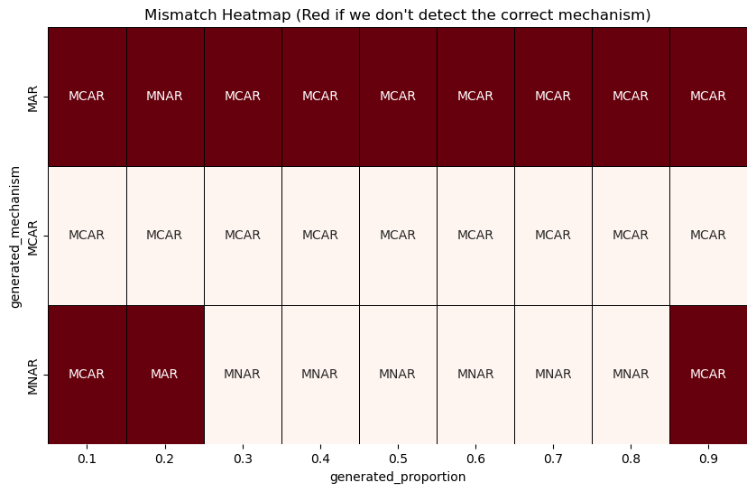

```python
import pandas as pd
import seaborn as sns
import matplotlib.pyplot as plt

# Data
data = {
    'mechanism': ['MCAR', 'MNAR', 'MCAR', 'MCAR', 'MCAR', 'MCAR', 'MCAR', 'MCAR', 'MCAR', 'MCAR',
                  'MAR', 'MNAR', 'MNAR', 'MNAR', 'MNAR', 'MNAR', 'MNAR', 'MCAR', 'MCAR', 'MCAR',
                  'MCAR', 'MCAR', 'MCAR', 'MCAR', 'MCAR', 'MCAR', 'MCAR'],
    'generated_mechanism': ['MAR', 'MAR', 'MAR', 'MAR', 'MAR', 'MAR', 'MAR', 'MAR', 'MAR', 'MNAR',
                            'MNAR', 'MNAR', 'MNAR', 'MNAR', 'MNAR', 'MNAR', 'MNAR', 'MNAR', 'MCAR',
                            'MCAR', 'MCAR', 'MCAR', 'MCAR', 'MCAR', 'MCAR', 'MCAR', 'MCAR'],
    'generated_proportion': [0.1, 0.2, 0.3, 0.4, 0.5, 0.6, 0.7, 0.8, 0.9, 0.1, 0.2, 0.3, 0.4, 0.5,
                             0.6, 0.7, 0.8, 0.9, 0.1, 0.2, 0.3, 0.4, 0.5, 0.6, 0.7, 0.8, 0.9]
}

df = pd.DataFrame(data)

# Create a pivot table with 'mechanism' as values for annotations
annotation_data = df.pivot_table(index='generated_mechanism', columns='generated_proportion', values='mechanism', aggfunc=lambda x: ' '.join(x))

# Create a column indicating where mechanism != generated_mechanism
df['mismatch'] = df['mechanism'] != df['generated_mechanism']

# Pivot the data for the heatmap
heatmap_data = df.pivot_table(index='generated_mechanism', columns='generated_proportion', values='mismatch', aggfunc='sum')

# Plot the heatmap
plt.figure(figsize=(10, 6))
sns.heatmap(heatmap_data, cmap="Reds", cbar=False, linewidths=0.5, linecolor='black', annot=annotation_data, fmt='')
plt.title("Mismatch Heatmap (Red if we don't detect the correct mechanism)")
plt.show()
```